# Data analysis with R and the tidyverse

### 1.4.4 Transforming the iris dataset

Note that the width and length columns in the tidied iris dataset are of type character (**chr**) instead of numeric (**dbl** or **int**). If we want to compute sums or other statistics on this table, we need to transform these columns into the appropriate type. We can do this with function mutate from package **dplyr**:

```r
ir <- ir %>%
   mutate(sepal_length = as.numeric(sepal_length),
          sepal_width  = as.numeric(sepal_width),
          petal_length = as.numeric(petal_length),
          petal_width  = as.numeric(petal_width))
```

### 1.4.5 visualizing the iris dataset

Let us now plot histograms for each flower feature to see if there is one that can be used to classify the two iris species:

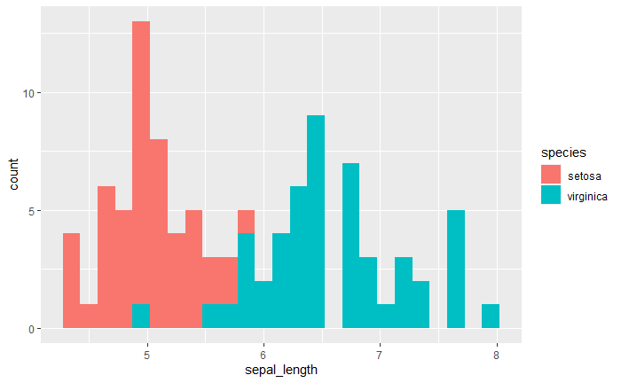

```r
# sepal length
ir %>%
  ggplot(aes(x=sepal_length, fill = species)) +
  geom_histogram(binwidth = 0.15)
```

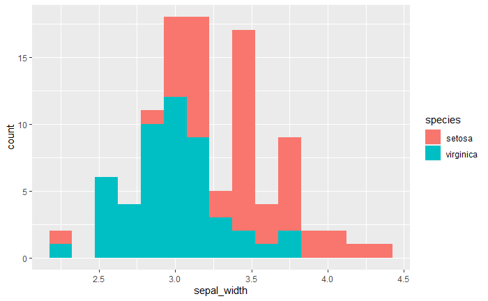

```r
# sepal width
ir %>%
  ggplot(aes(x=sepal_width, fill = species)) +
  geom_histogram(binwidth = 0.15)
```

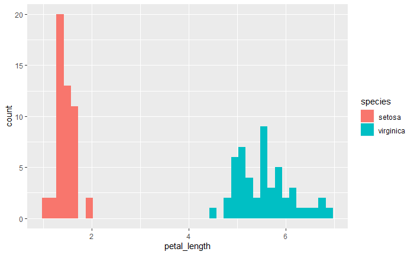

```r
# petal length
ir %>%
  ggplot(aes(x=petal_length, fill=species)) +
  geom_histogram(binwidth = 0.15)
```

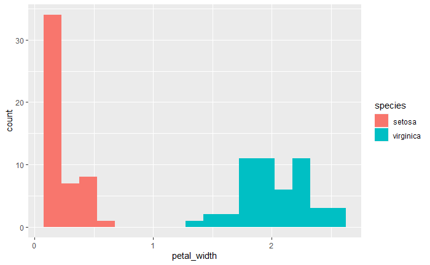

```r
# petal width
ir %>%
  ggplot(aes(x=petal_width, fill=species)) +
  geom_histogram(binwidth = 0.15)
```

### 1.4.6 modeling

Thanks to the above plots, we know that we can use petal length and width to differentiate between a flower from the species Iris setosa and the species Iris virginica. Under the assumption that we are only dealing with flowers from these two species, let us use our observations to propose a simple model for iris flower classification:

```r
# the model is implemented with a function that takes 2 parameters
which_species <- function(petal_length, petal_width){

  if (petal_length <= 3 && petal_width <= 1){
    print("Iris setosa")
    }
  else{
    print("Iris virginica")
  }

}
```

```r
# We can call the function with 2 specific values to get an answer
which_species(petal_length=2, petal_width=0.5)
```

```
[1] "Iris setosa"
```

```r
which_species(petal_length=10, petal_width=0.5)
```

```
[1] "Iris virginica"
```

# 2 Import and the tibble

## 2.1 Importing data into R

In Part 1, you saw that the first step in any data analysis pipeline is importing your tables into R. You do this to take advantage of R’s functions, which simplify the manipulation of your data.

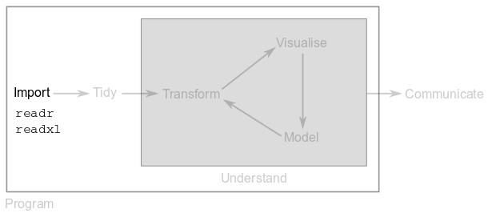

There are two packages in the tidyverse that make data import into R a matter of a single line of code.

Package **readr** provides functions to import data tables stored in plain-text files, such as “comma-separated value” (.csv) or “tab-separated value” (.tsv) files.

Package **readxl** provides functions to import data stored in Microsoft Excel files. These functions also let you import from specific sheets or ranges within the Excel file.

## 2.2 Importing from plain-text files

To demarcate the content of each cell in a file, people use special characters like commas, tabs, pipes, etc. The extension of plain-text files is often a good hint of what delimiter has been used. For example, csv files should use “commas” as the delimiter, whereas tsv files should use “tabs”. Nevertheless, you can find csv or tsv files that are delimited with different characters.

The first step in data import is locating the file in your computer or in a remote location (e.g. by URL). The most important parameter for readr’s functions is the path to the file of interest.

In this part, you are going to import files located on internet. Packages **tidyverse** and **readxl** must be loaded.

### 2.2.1 Importing a tsv file

Let’s start by learning how to import a tsv file:

```r
who_ref <- read_tsv("http://cbdm-01.zdv.uni-mainz.de/~stalbrec/RcourseData/who_ref.tsv")
who_ref
```

| country | year | cases | population |
| --- | --- | --- | --- |
| Afghanistan | 1999 | 745 | 19987071 |
| Afghanistan | 2000 | 2666 | 20595360 |
| Brazil | 1999 | 37737 | 172006362 |
| Brazil | 2000 | 80488 | 174504898 |
| China | 1999 | 212258 | 1272915272 |
| China | 2000 | 213766 | 1280428583 |

| country <chr> | year <dbl> | cases <dbl> | population <dbl> |  |
| --- | --- | --- | --- | --- |
| Afghanistan | 1999 | 745 | 19987071 |  |
| Afghanistan | 2000 | 2666 | 20595360 |  |
| Brazil | 1999 | 37737 | 172006362 |  |
| Brazil | 2000 | 80488 | 174504898 |  |
| China | 1999 | 212258 | 1272915272 |  |
| China | 2000 | 213766 | 1280428583 |  |

6 rows

### 2.2.2 Importing a csv file

Importing a csv file is very similar:

```r
who1 <- read_csv("http://cbdm-01.zdv.uni-mainz.de/~stalbrec/RcourseData/who1.csv")
who1
```

| country | year | type | count |
| --- | --- | --- | --- |
| Afghanistan | 1999 | cases | 745 |
| Afghanistan | 1999 | population | 19987071 |
| Afghanistan | 2000 | cases | 2666 |
| Afghanistan | 2000 | population | 20595360 |
| Brazil | 1999 | cases | 37737 |
| Brazil | 1999 | population | 172006362 |
| Brazil | 2000 | cases | 80488 |
| Brazil | 2000 | population | 174504898 |
| China | 1999 | cases | 212258 |
| China | 1999 | population | 1272915272 |

[output cut: 2 more lines]

| country <chr> | year <dbl> | type <chr> | count <dbl> |  |
| --- | --- | --- | --- | --- |
| Afghanistan | 1999 | cases | 745 |  |
| Afghanistan | 1999 | population | 19987071 |  |
| Afghanistan | 2000 | cases | 2666 |  |
| Afghanistan | 2000 | population | 20595360 |  |
| Brazil | 1999 | cases | 37737 |  |
| Brazil | 1999 | population | 172006362 |  |
| Brazil | 2000 | cases | 80488 |  |
| Brazil | 2000 | population | 174504898 |  |
| China | 1999 | cases | 212258 |  |
| China | 1999 | population | 1272915272 |  |

1-10 of 12 rows

Note how simple the syntax for data import is: you choose the name of a variable to store your table, use the **<-** operator (written with 2 characters: **<** and **-**), call the appropriate **readr** function and specify the location of your file.

### 2.2.3 Make the example data locally available

So far, we used URLs to access the datasets used for the examples. However, you can also download them to save them locally and work with the files directly. There is a folder online, available for download via this link: “http://cbdm-01.zdv.uni-mainz.de/~stalbrec/RcourseData/datasets.zip”. Download it, unzip it and save the files under “datasets”. You should also use an R script (or several scripts) to write the code for the upcoming examples. Put such scripts in an appropriate folder together with the “datasets” folder. If you then set your “Working Directory” to the location of your R scripts, you can access the example files wih a direct path like this “./datasets/andrade_lab.csv” (see next small exercise).

To change your “Working Directory”, go to “Session” -> “Set Working Directory” -> “To source file location”

### 2.2.4 Exercise 2.1

Read file `./datasets/andrade_lab.csv` into variable **al** and show the content of the variable.

### 2.2.5 Importing a text file

If the column delimiter of a file is not obvious from its extension and the person in charge of the file didn’t provide this information, you must first figure out which delimiter was used. For example, open the following file `./datasets/who2.txt`.

Since the delimiter is a **-**, we need to call **read_delim** to import:

```r
who2 <- read_delim("http://cbdm-01.zdv.uni-mainz.de/~stalbrec/RcourseData/who2.txt", delim = "-")
who2
```

| country | year | rate |
| --- | --- | --- |
| Afghanistan | 1999 | 745/19987071 |
| Afghanistan | 2000 | 2666/20595360 |
| Brazil | 1999 | 37737/172006362 |
| Brazil | 2000 | 80488/174504898 |
| China | 1999 | 212258/1272915272 |
| China | 2000 | 213766/1280428583 |

| country <chr> | year <dbl> | rate <chr> |  |  |
| --- | --- | --- | --- | --- |
| Afghanistan | 1999 | 745/19987071 |  |  |
| Afghanistan | 2000 | 2666/20595360 |  |  |
| Brazil | 1999 | 37737/172006362 |  |  |
| Brazil | 2000 | 80488/174504898 |  |  |
| China | 1999 | 212258/1272915272 |  |  |
| China | 2000 | 213766/1280428583 |  |  |

6 rows

Note that in this special case, you have to specify the delimiter using parameter **delim**.

### 2.2.6 Exercise 2.2

From its extension, file `./datasets/andrade_lab.tsv` is supposed to be tab-separated. Read the file with function **read_tsv** into variable **al** and show its contents. What character is the delimiter in this file? Use the appropriate **readr** function to import this table into R.

## 2.3 Importing from Excel files

The syntax to import from Excel files is very similar to the one used above. By default, function **read_excel** imports from the first available sheet in the Excel workbook.

Load a EXCEL sheet via the following path in your lacal folder. Open the file also with EXCEL to see its content.

**./datasets/who_split.xlsx**

```r
who_cases <- read_excel("datasets/who_split.xlsx") # will load first sheet named 'cases'
who_cases
```

| country | 1999 | 2000 |
| --- | --- | --- |
| Afghanistan | 745 | 2666 |
| Brazil | 37737 | 80488 |
| China | 212258 | 213766 |

| country <chr> | 1999 <dbl> | 2000 <dbl> |  |  |
| --- | --- | --- | --- | --- |
| Afghanistan | 745 | 2666 |  |  |
| Brazil | 37737 | 80488 |  |  |
| China | 212258 | 213766 |  |  |

3 rows

If you want data from a different sheet, you must use parameter sheet:

```r
who_pop <- read_excel("datasets/who_split.xlsx",
                      sheet = "population")
who_pop
```

| country | 1999 | 2000 |
| --- | --- | --- |
| Afghanistan | 19987071 | 20595360 |
| Brazil | 172006362 | 174504898 |
| China | 1272915272 | 1280428583 |

| country <chr> | 1999 <dbl> | 2000 <dbl> |  |  |
| --- | --- | --- | --- | --- |
| Afghanistan | 19987071 | 20595360 |  |  |
| Brazil | 172006362 | 174504898 |  |  |
| China | 1272915272 | 1280428583 |  |  |

3 rows

You can also specify a range to import from:

```r
who_pop_99 <- read_excel("datasets/who_split.xlsx",
                         sheet = "population",
                         range = "A1:B4")
who_pop_99
```

| country | 1999 |
| --- | --- |
| Afghanistan | 19987071 |
| Brazil | 172006362 |
| China | 1272915272 |

| country <chr> | 1999 <dbl> |  |  |  |
| --- | --- | --- | --- | --- |
| Afghanistan | 19987071 |  |  |  |
| Brazil | 172006362 |  |  |  |
| China | 1272915272 |  |  |  |

3 rows

### 2.3.1 Exercise 2.3

Copy the following file to the **datasets** subfolder: **./datasets/andrade_lab.xlsx**

Import the list of PhD students in Andrade Lab from the file. Choose a variable name to store the file contents.

## 2.4 The tibble

Reading files with **readr** or **readxl** functions results in the creation of a variable of type **tbl_df** instead of R’s traditional data frame (type **data.frame**). This is because one of the unifying features of the **tidyverse** is the tibble (type **tbl_df**).

```r
# Using base R function to import CSV files
who1_df <- read.csv("http://cbdm-01.zdv.uni-mainz.de/~stalbrec/RcourseData/who1.csv",
                    stringsAsFactors=TRUE)
class(who1_df)
```

```
[1] "data.frame"
```

```r
# Using readr function to import CSV files
who1_tb <- read_csv("http://cbdm-01.zdv.uni-mainz.de/~stalbrec/RcourseData/who1.csv")
class(who1_tb)
```

```
[1] "spec_tbl_df" "tbl_df"      "tbl"         "data.frame"
```

tibbles are data frames but they tweak some old behaviors that make our life easier when analyzing data.

To start with, printing the content of a tibble shows a rich output that gives information about the data type of each column. By contrast, data frames just show the records as is:

```r
who1_tb
```

| country | year | type | count |
| --- | --- | --- | --- |
| Afghanistan | 1999 | cases | 745 |
| Afghanistan | 1999 | population | 19987071 |
| Afghanistan | 2000 | cases | 2666 |
| Afghanistan | 2000 | population | 20595360 |
| Brazil | 1999 | cases | 37737 |
| Brazil | 1999 | population | 172006362 |
| Brazil | 2000 | cases | 80488 |
| Brazil | 2000 | population | 174504898 |
| China | 1999 | cases | 212258 |
| China | 1999 | population | 1272915272 |

[output cut: 2 more lines]

| country <chr> | year <dbl> | type <chr> | count <dbl> |  |
| --- | --- | --- | --- | --- |
| Afghanistan | 1999 | cases | 745 |  |
| Afghanistan | 1999 | population | 19987071 |  |
| Afghanistan | 2000 | cases | 2666 |  |
| Afghanistan | 2000 | population | 20595360 |  |
| Brazil | 1999 | cases | 37737 |  |
| Brazil | 1999 | population | 172006362 |  |
| Brazil | 2000 | cases | 80488 |  |
| Brazil | 2000 | population | 174504898 |  |
| China | 1999 | cases | 212258 |  |
| China | 1999 | population | 1272915272 |  |

1-10 of 12 rows

Also, tibbles never change the type of the inputs. While column country is of type character in **who1_tb**, it could be imported as a **factor** in **who1_df** depending on the R version and settings. For the sake of this demonstration, we used option **stringsAsFactors=TRUE** when importing the data frame with the base R function **read.csv**. Except if required, I recommend users importing data with base R functions such as **read.csv** to set this option to FALSE (**stringsAsFactors=FALSE**).

```r
class(who1_tb$country)
```

```
[1] "character"
```

```r
class(who1_df$country)
```

```
[1] "factor"
```

Factor can be problematic to some users (especially beginners): in the data frame, country cannot take other values other than the ones already imported. If we want to append information about a new country to our table, it will be added but as an **NA** (Not Applicable):

```r
# Adding a new row
tmp <- rbind(who1_df, c("Mexico", 1999, "cases", 100))
# Printing the bottom of the table (country is "NA" on last row)
tmp %>% tail()
```

|  | country | year | type | count |
| --- | --- | --- | --- | --- |
| 8 | Brazil | 2000 | population | 174504898 |
| 9 | China | 1999 | cases | 212258 |
| 10 | China | 1999 | population | 1272915272 |
| 11 | China | 2000 | cases | 213766 |
| 12 | China | 2000 | population | 1280428583 |
| 13 | NA | 1999 | cases | 100 |

|  | country <fctr> | year <chr> | type <fctr> | count <chr> |
| --- | --- | --- | --- | --- |
| 8 | Brazil | 2000 | population | 174504898 |
| 9 | China | 1999 | cases | 212258 |
| 10 | China | 1999 | population | 1272915272 |
| 11 | China | 2000 | cases | 213766 |
| 12 | China | 2000 | population | 1280428583 |
| 13 | NA | 1999 | cases | 100 |

6 rows

Since packages outside the tidyverse use data frames, you might want to coerce them to tibbles with function **as_tibble**:

```r
who1_df <- as_tibble(who1_df)
```

In addition, it’s possible for a tibble to have column names that are not valid R variable names that are limited to specific rules. For example, they might not start with a letter, or they might contain unusual characters:

```r
unusual <- read_tsv("http://cbdm-01.zdv.uni-mainz.de/~stalbrec/RcourseData/unusual.tsv")
unusual
```

| :) | with space | 2000 |
| --- | --- | --- |
| smile | space | number |

| :) <chr> | with space <chr> | 2000 <chr> |  |  |
| --- | --- | --- | --- | --- |
| smile | space | number |  |  |

1 row

To refer to these column names, you have to use back-ticks:

```r
unusual$`:)`
```

```
[1] "smile"
```

Finally, you can create your own tibbles with function tibble:

```r
stocks <- tibble(
  year    = c(2015, 2015, 2015, 2015, 2016, 2016, 2016),
  qtr     = c(   1,    2,    3,    4,    2,    3,    4),
  revenue = c(1.88, 0.59, 0.35,   NA, 0.92, 0.17, 2.66)
)
stocks
```

| year | qtr | revenue |
| --- | --- | --- |
| 2015 | 1 | 1.88 |
| 2015 | 2 | 0.59 |
| 2015 | 3 | 0.35 |
| 2015 | 4 | NA |
| 2016 | 2 | 0.92 |
| 2016 | 3 | 0.17 |
| 2016 | 4 | 2.66 |

| year <dbl> | qtr <dbl> | revenue <dbl> |  |  |
| --- | --- | --- | --- | --- |
| 2015 | 1 | 1.88 |  |  |
| 2015 | 2 | 0.59 |  |  |
| 2015 | 3 | 0.35 |  |  |
| 2015 | 4 | NA |  |  |
| 2016 | 2 | 0.92 |  |  |
| 2016 | 3 | 0.17 |  |  |
| 2016 | 4 | 2.66 |  |  |

7 rows

# 3 Tidy data

## 3.1 Foreword

The rationale behind the tidy data philosophy is to organize the data you imported to or created in R into a consistent format. The goal is to spend less time formatting your data and more time analyzing it. If your data is tidy you will be able to use it seamlessly across the **tidyverse**.

This part will show you how to use the functions from package **tidyr** to tidy up your data. As a result, data transformations and visualizations will be a real piece of cake.

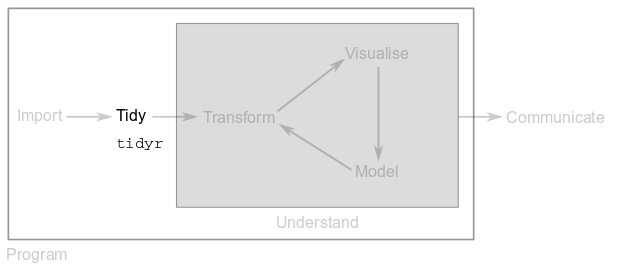

## 3.2 What is tidy data?

There are three simple and interrelated rules that make a dataset tidy:

1. Each **observation/sample** must be reported in its own **row**
2. Each **variable/feature** describing the sample must have its own **column**
3. Each **value** must have its own **cell**

We will import some tables and check if they fulfill the above rules.

### 3.2.1 Exercise 3.1

Import file `./datasets/who1.csv` into variable **who1** and show the imported data. Is the who1 dataset tidy?

### 3.2.2 Exercise 3.2

Import file `./datasets/who2.txt` into variable **who2** and show the imported data. Is the **who2** dataset tidy?

### 3.2.3 Exercise 3.3

Import sheet population from file **datasets/who_split.xlsx** into variable **who_pop** and show the imported data. Is **who_pop** tidy?

### 3.2.4 Why tidy data?

Why ensure that your data is tidy? There are two main advantages:

1. If you have a consistent data structure, it’s easier to learn the tools that work with it because they have an underlying uniformity. The functions in the tidyverse all work flawlessly with tidy datasets.
2. Placing variables in columns allows R’s vectorised nature to shine.

The principles of tidy data seem very obvious. Unfortunately, most data that you will encounter will be untidy. There are two main reasons:

1. Most people aren’t familiar with the principles of tidy data.
2. Data is often organized to facilitate some use other than analysis.

This means that for most real analyzes, you will need to tidy your data.

## 3.3 Spreading and gathering

When you are in front of a dataset, the first step is always to understand what the observations and the features that describe them are. The second step is to solve one of two common problems:

1. **One observation** is scattered across **multiple rows**
2. **One feature** is spread across **multiple columns**

To fix these problems, the **tidyverse** provides you with functions **spread** and **gather**.

### 3.3.1 Spreading

You use function **spread** for Problem 1: one observation is scattered across multiple rows. That’s exactly the problem we saw in table **who1**:

```r
who1
```

| country | year | type | count |
| --- | --- | --- | --- |
| Afghanistan | 1999 | cases | 745 |
| Afghanistan | 1999 | population | 19987071 |
| Afghanistan | 2000 | cases | 2666 |
| Afghanistan | 2000 | population | 20595360 |
| Brazil | 1999 | cases | 37737 |
| Brazil | 1999 | population | 172006362 |
| Brazil | 2000 | cases | 80488 |
| Brazil | 2000 | population | 174504898 |
| China | 1999 | cases | 212258 |
| China | 1999 | population | 1272915272 |

[output cut: 2 more lines]

| country <chr> | year <dbl> | type <chr> | count <dbl> |  |
| --- | --- | --- | --- | --- |
| Afghanistan | 1999 | cases | 745 |  |
| Afghanistan | 1999 | population | 19987071 |  |
| Afghanistan | 2000 | cases | 2666 |  |
| Afghanistan | 2000 | population | 20595360 |  |
| Brazil | 1999 | cases | 37737 |  |
| Brazil | 1999 | population | 172006362 |  |
| Brazil | 2000 | cases | 80488 |  |
| Brazil | 2000 | population | 174504898 |  |
| China | 1999 | cases | 212258 |  |
| China | 1999 | population | 1272915272 |  |

1-10 of 12 rows

**who1** is an excerpt of the World Health Organization Tuberculosis Report. Each observation, a country in a year in this case, should be accompanied by that year’s number of tuberculosis cases and population. However, each country-year pair appears twice in who1: one for the tuberculosis cases and one for the country’s population.

To tidy up this dataset, we need to spread column count into new columns, one for each of the keys specified in column type:

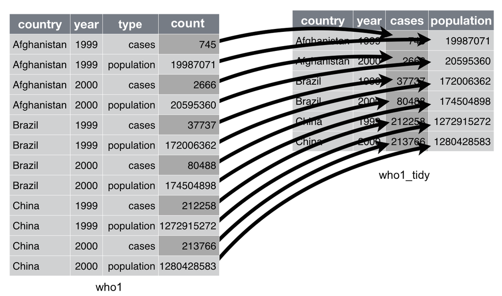

**Figure**: Adapted from “R for Data Science”, Chapter 12

We can do this with function **spread** as follows:

```r
who1_tidy <- who1 %>%
   spread(value = count, key = type)
who1_tidy
```

| country | year | cases | population |
| --- | --- | --- | --- |
| Afghanistan | 1999 | 745 | 19987071 |
| Afghanistan | 2000 | 2666 | 20595360 |
| Brazil | 1999 | 37737 | 172006362 |
| Brazil | 2000 | 80488 | 174504898 |
| China | 1999 | 212258 | 1272915272 |
| China | 2000 | 213766 | 1280428583 |

| country <chr> | year <dbl> | cases <dbl> | population <dbl> |  |
| --- | --- | --- | --- | --- |
| Afghanistan | 1999 | 745 | 19987071 |  |
| Afghanistan | 2000 | 2666 | 20595360 |  |
| Brazil | 1999 | 37737 | 172006362 |  |
| Brazil | 2000 | 80488 | 174504898 |  |
| China | 1999 | 212258 | 1272915272 |  |
| China | 2000 | 213766 | 1280428583 |  |

6 rows

Note the syntax used to tidy up **who1**:

1. Choose a variable name to store the tidy data (this could very well be **who1** again).
2. Use the assignment operator **<-**.
3. Specify the variable that we want to tidy up.
4. Use the pipe operator **%>%** to channel the content of who1 to the function **spread** (more on the pipe operator later in this Part).
5. Call function **spread** and specify the column containing the **values** that we want to spread and the column containing the new variable names (known as the **key** column).

### 3.3.2 Gathering

You use function **gather** for Problem 2: **one feature** is spread across **multiple columns**. That is exactly the problem we saw in, for example, table *who_cases* from the Excel file *who_split.xlsx*:

```r
who_cases
```

| country | 1999 | 2000 |
| --- | --- | --- |
| Afghanistan | 745 | 2666 |
| Brazil | 37737 | 80488 |
| China | 212258 | 213766 |

| country <chr> | 1999 <dbl> | 2000 <dbl> |  |  |
| --- | --- | --- | --- | --- |
| Afghanistan | 745 | 2666 |  |  |
| Brazil | 37737 | 80488 |  |  |
| China | 212258 | 213766 |  |  |

3 rows

The column names 1999 and 2000 are actually values of the variable year, which means that each row represents two observations instead of one.

To tidy this dataset, we need to gather columns 1999 and 2000 into a new pair of variables:

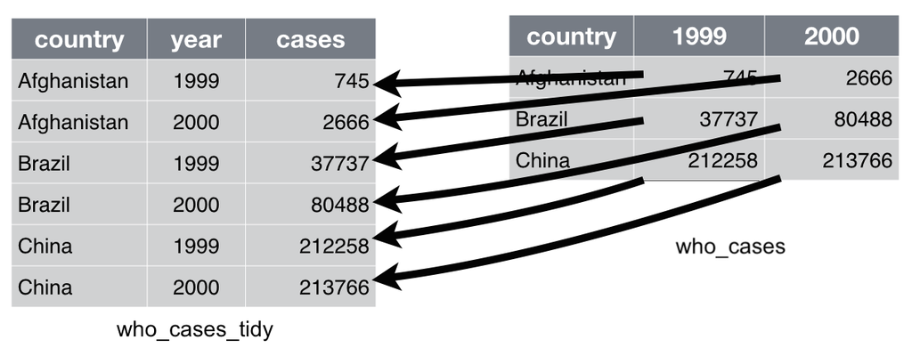

**Figure**: Adapted from “R for Data Science”, Chapter 12

We can do this with function **gather** as follows:

```r
who_cases_tidy <- who_cases %>%
   gather(`1999`, `2000`, key = "year", value = "cases")
who_cases_tidy
```

| country | year | cases |
| --- | --- | --- |
| Afghanistan | 1999 | 745 |
| Brazil | 1999 | 37737 |
| China | 1999 | 212258 |
| Afghanistan | 2000 | 2666 |
| Brazil | 2000 | 80488 |
| China | 2000 | 213766 |

| country <chr> | year <chr> | cases <dbl> |  |  |
| --- | --- | --- | --- | --- |
| Afghanistan | 1999 | 745 |  |  |
| Brazil | 1999 | 37737 |  |  |
| China | 1999 | 212258 |  |  |
| Afghanistan | 2000 | 2666 |  |  |
| Brazil | 2000 | 80488 |  |  |
| China | 2000 | 213766 |  |  |

6 rows

Note the syntax used to tidy up *who_cases*:

1. Choose a variable name to store the tidy data (this could very well be *who_cases* again).
2. Use the assignment operator **<-**.
3. Specify the variable that we want to tidy up.
4. Use the pipe operator **%>%** to channel the contents of *who_cases* to function **gather**.
5. Call function **gather** and specify the columns we want to merge, the name of the column that will contain the merged **keys** and the name of the column that will contain the **value** for the number of tuberculosis cases per country.

### 3.3.3 Exercise 3.4

Consider the following tibble, which records heights and weights of 3 students:

```r
students <- tibble(name = rep(c("Jonas", "Ines", "Hanna"), each = 2),
                   type = rep(c("height", "weight"), 3),
                   measure = c(1.83, 81, 1.75, 71, 1.69, 55))
students
```

| name | type | measure |
| --- | --- | --- |
| Jonas | height | 1.83 |
| Jonas | weight | 81.00 |
| Ines | height | 1.75 |
| Ines | weight | 71.00 |
| Hanna | height | 1.69 |
| Hanna | weight | 55.00 |

| name <chr> | type <chr> | measure <dbl> |  |  |
| --- | --- | --- | --- | --- |
| Jonas | height | 1.83 |  |  |
| Jonas | weight | 81.00 |  |  |
| Ines | height | 1.75 |  |  |
| Ines | weight | 71.00 |  |  |
| Hanna | height | 1.69 |  |  |
| Hanna | weight | 55.00 |  |  |

6 rows

Use the appropriate **tidyr** function on variable **students** to make it tidy.

### 3.3.4 Exercise 3.5

Consider the following tibble, which records the expression of 4 genes at 3 different time points (d00, d02 and d04):

```r
genes <- tibble(symbol = c("DMD", "MYOG", "MYF5", "MYOD1"),
                d00 = c(0.697, 0.844, 1.878, 1.622),
                d02 = c(1.986, 0.051, 0.887, 1.313),
                d04 = c(0.157, 0.774, 1.507, 0.628))
genes
```

| symbol | d00 | d02 | d04 |
| --- | --- | --- | --- |
| DMD | 0.697 | 1.986 | 0.157 |
| MYOG | 0.844 | 0.051 | 0.774 |
| MYF5 | 1.878 | 0.887 | 1.507 |
| MYOD1 | 1.622 | 1.313 | 0.628 |

| symbol <chr> | d00 <dbl> | d02 <dbl> | d04 <dbl> |  |
| --- | --- | --- | --- | --- |
| DMD | 0.697 | 1.986 | 0.157 |  |
| MYOG | 0.844 | 0.051 | 0.774 |  |
| MYF5 | 1.878 | 0.887 | 1.507 |  |
| MYOD1 | 1.622 | 1.313 | 0.628 |  |

4 rows

Here, an observation should be a gene at a given time point. Use the appropriate tidyr function on variable genes to make it tidy.

## 3.4 Separating and uniting

### 3.4.1 Separating

When one column in a dataset contains two variables, we’ll need to use function **separate** to fix the issue. That’s exactly the problem we saw in table *who2*:

```r
who2
```

| country | year | rate |
| --- | --- | --- |
| Afghanistan | 1999 | 745/19987071 |
| Afghanistan | 2000 | 2666/20595360 |
| Brazil | 1999 | 37737/172006362 |
| Brazil | 2000 | 80488/174504898 |
| China | 1999 | 212258/1272915272 |
| China | 2000 | 213766/1280428583 |

| country <chr> | year <dbl> | rate <chr> |  |  |
| --- | --- | --- | --- | --- |
| Afghanistan | 1999 | 745/19987071 |  |  |
| Afghanistan | 2000 | 2666/20595360 |  |  |
| Brazil | 1999 | 37737/172006362 |  |  |
| Brazil | 2000 | 80488/174504898 |  |  |
| China | 1999 | 212258/1272915272 |  |  |
| China | 2000 | 213766/1280428583 |  |  |

6 rows

Column rate contains both cases and population, so we need to split it in two:

We can do this with function **separate** as follows:

```r
who2_tidy <- who2 %>%
   separate(rate, into = c("cases", "population"), sep = "/")
who2_tidy
```

| country | year | cases | population |
| --- | --- | --- | --- |
| Afghanistan | 1999 | 745 | 19987071 |
| Afghanistan | 2000 | 2666 | 20595360 |
| Brazil | 1999 | 37737 | 172006362 |
| Brazil | 2000 | 80488 | 174504898 |
| China | 1999 | 212258 | 1272915272 |
| China | 2000 | 213766 | 1280428583 |

| country <chr> | year <dbl> | cases <chr> | population <chr> |  |
| --- | --- | --- | --- | --- |
| Afghanistan | 1999 | 745 | 19987071 |  |
| Afghanistan | 2000 | 2666 | 20595360 |  |
| Brazil | 1999 | 37737 | 172006362 |  |
| Brazil | 2000 | 80488 | 174504898 |  |
| China | 1999 | 212258 | 1272915272 |  |
| China | 2000 | 213766 | 1280428583 |  |

6 rows

Note the syntax used to tidy up **who2**:

1. Choose a variable name to store the tidy data (this could very well be **who2** again).
2. Use the assignment operator **<-**.
3. Specify the variable that we want to tidy up.
4. Use the pipe operator **%>%** to channel the contents of **who2** to function **separate**.
5. Call function **separate** and specify the column we want to split, the name of the new columns and the separator that is currently merging the variables.

### 3.4.2 Uniting

```r
who3 <- read_tsv("http://cbdm-01.zdv.uni-mainz.de/~stalbrec/RcourseData/who3.tsv")
who3
```

| country | century | year | rate |
| --- | --- | --- | --- |
| Afghanistan | 19 | 99 | 745/19987071 |
| Afghanistan | 20 | 00 | 2666/20595360 |
| Brazil | 19 | 99 | 37737/172006362 |
| Brazil | 20 | 00 | 80488/174504898 |
| China | 19 | 99 | 212258/1272915272 |
| China | 20 | 00 | 213766/1280428583 |

| country <chr> | century <dbl> | year <chr> | rate <chr> |  |
| --- | --- | --- | --- | --- |
| Afghanistan | 19 | 99 | 745/19987071 |  |
| Afghanistan | 20 | 00 | 2666/20595360 |  |
| Brazil | 19 | 99 | 37737/172006362 |  |
| Brazil | 20 | 00 | 80488/174504898 |  |
| China | 19 | 99 | 212258/1272915272 |  |
| China | 20 | 00 | 213766/1280428583 |  |

6 rows

Column **century** and **year** can be combined into a single column called **year**:

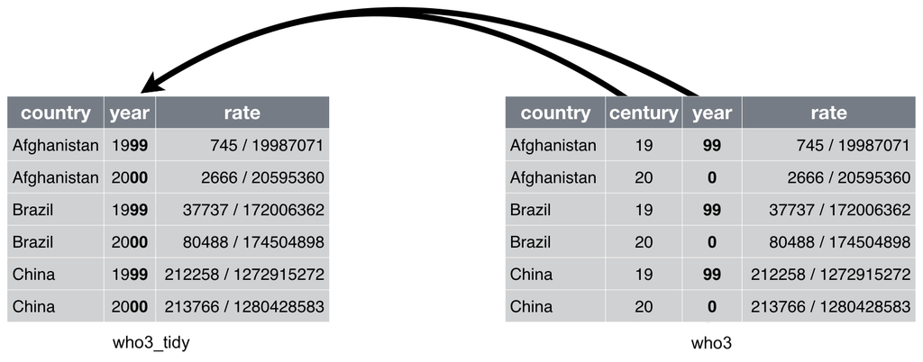

**Figure**: Adapted from “R for Data Science”, Chapter12

We can do this with function **unite** as follows:

```r
who3_tidy <- who3 %>%
   unite(century, year, col = "year", sep = "")
who3_tidy
```

| country | year | rate |
| --- | --- | --- |
| Afghanistan | 1999 | 745/19987071 |
| Afghanistan | 2000 | 2666/20595360 |
| Brazil | 1999 | 37737/172006362 |
| Brazil | 2000 | 80488/174504898 |
| China | 1999 | 212258/1272915272 |
| China | 2000 | 213766/1280428583 |

| country <chr> | year <chr> | rate <chr> |  |  |
| --- | --- | --- | --- | --- |
| Afghanistan | 1999 | 745/19987071 |  |  |
| Afghanistan | 2000 | 2666/20595360 |  |  |
| Brazil | 1999 | 37737/172006362 |  |  |
| Brazil | 2000 | 80488/174504898 |  |  |
| China | 1999 | 212258/1272915272 |  |  |
| China | 2000 | 213766/1280428583 |  |  |

6 rows

Note the syntax used to tidy up who3:

1. Choose a variable name to store the tidy data (this could very well be **who3** again).
2. Use the assignment operator **<-**.
3. Specify the variable that we want to tidy up.
4. Use the pipe operator **%>%** to channel the contents of **who3** to function **unite**.
5. Call function **unite** and specify the columns we want to merge, the name of the new column and the separator that we want to use to merge the column values.

### 3.4.3 Exercise 3.6

Consider the following tibble, which records heights and weights of 3 students:

```r
students <- tibble(name = c("Jonas", "Ines", "Hanna"),
                   ratio = c("81/1.83", "71/1.75", "55/1.69"))
students
```

| name | ratio |
| --- | --- |
| Jonas | 81/1.83 |
| Ines | 71/1.75 |
| Hanna | 55/1.69 |

| name <chr> | ratio <chr> |  |  |  |
| --- | --- | --- | --- | --- |
| Jonas | 81/1.83 |  |  |  |
| Ines | 71/1.75 |  |  |  |
| Hanna | 55/1.69 |  |  |  |

3 rows

Use the appropriate **tidyr** function on variable **students** to make it tidy.

### 3.4.4 Exercise 3.7

Consider the following tibble, which records the price of 4 drugs:

```r
drugs <- tibble(name = c("penicillin", "insuline", "aspirin", "lanoxin"),
                euros = c(13, 17, 5, 25),
                cents = c(81, 20, 14, 12))
drugs
```

| name | euros | cents |
| --- | --- | --- |
| penicillin | 13 | 81 |
| insuline | 17 | 20 |
| aspirin | 5 | 14 |
| lanoxin | 25 | 12 |

| name <chr> | euros <dbl> | cents <dbl> |  |  |
| --- | --- | --- | --- | --- |
| penicillin | 13 | 81 |  |  |
| insuline | 17 | 20 |  |  |
| aspirin | 5 | 14 |  |  |
| lanoxin | 25 | 12 |  |  |

4 rows

Use the appropriate **tidyr** function on variable drugs to make it tidy.

## 3.5 The %>% operator

As you know already, we channel the contents of a **tibble** to the different **tidyr** functions using the pipe operator: **%>%**.

Pipes are a powerful tool for clearly expressing the operation we want to perform on a variable. In addition, they can be used to apply a sequence of operations to a variable.

Table *who3*, for example, has two problems: **cases** and **population** are expressed as a **rate** and **year** is split in columns **century** and **year**:

```r
who3
```

| country | century | year | rate |
| --- | --- | --- | --- |
| Afghanistan | 19 | 99 | 745/19987071 |
| Afghanistan | 20 | 00 | 2666/20595360 |
| Brazil | 19 | 99 | 37737/172006362 |
| Brazil | 20 | 00 | 80488/174504898 |
| China | 19 | 99 | 212258/1272915272 |
| China | 20 | 00 | 213766/1280428583 |

| country <chr> | century <dbl> | year <chr> | rate <chr> |  |
| --- | --- | --- | --- | --- |
| Afghanistan | 19 | 99 | 745/19987071 |  |
| Afghanistan | 20 | 00 | 2666/20595360 |  |
| Brazil | 19 | 99 | 37737/172006362 |  |
| Brazil | 20 | 00 | 80488/174504898 |  |
| China | 19 | 99 | 212258/1272915272 |  |
| China | 20 | 00 | 213766/1280428583 |  |

6 rows

So, we clearly need two steps to tidy up this dataset:

```r
who3_tidy <- who3 %>%
   separate(rate, into = c("cases", "population"), sep = "/")

who3_tidy <- who3_tidy %>%
   unite(century, year, col = "yyyy", sep = "")

who3_tidy
```

| country | yyyy | cases | population |
| --- | --- | --- | --- |
| Afghanistan | 1999 | 745 | 19987071 |
| Afghanistan | 2000 | 2666 | 20595360 |
| Brazil | 1999 | 37737 | 172006362 |
| Brazil | 2000 | 80488 | 174504898 |
| China | 1999 | 212258 | 1272915272 |
| China | 2000 | 213766 | 1280428583 |

| country <chr> | yyyy <chr> | cases <chr> | population <chr> |  |
| --- | --- | --- | --- | --- |
| Afghanistan | 1999 | 745 | 19987071 |  |
| Afghanistan | 2000 | 2666 | 20595360 |  |
| Brazil | 1999 | 37737 | 172006362 |  |
| Brazil | 2000 | 80488 | 174504898 |  |
| China | 1999 | 212258 | 1272915272 |  |
| China | 2000 | 213766 | 1280428583 |  |

6 rows

Thanks to the pipe, we can apply these two operations to *who3* in one go:

```r
who3_tidy <- who3 %>%
  separate(rate, into = c("cases", "population"), sep = "/") %>%
  unite(century, year, col = "yyyy", sep = "")
who3_tidy
```

| country | yyyy | cases | population |
| --- | --- | --- | --- |
| Afghanistan | 1999 | 745 | 19987071 |
| Afghanistan | 2000 | 2666 | 20595360 |
| Brazil | 1999 | 37737 | 172006362 |
| Brazil | 2000 | 80488 | 174504898 |
| China | 1999 | 212258 | 1272915272 |
| China | 2000 | 213766 | 1280428583 |

| country <chr> | yyyy <chr> | cases <chr> | population <chr> |  |
| --- | --- | --- | --- | --- |
| Afghanistan | 1999 | 745 | 19987071 |  |
| Afghanistan | 2000 | 2666 | 20595360 |  |
| Brazil | 1999 | 37737 | 172006362 |  |
| Brazil | 2000 | 80488 | 174504898 |  |
| China | 1999 | 212258 | 1272915272 |  |
| China | 2000 | 213766 | 1280428583 |  |

6 rows

Note that this process reads almost like natural language:

1. We channel (or pipe) the content of *who3* to function **separate**.
2. **separate** splits column rate into columns *cases* and *population* using “/” as separator.
3. The result of **separate** is piped to function **unite**.
4. **unite** combines columns *century* and *year* into column **yyyy** using nothing (empty string ““) as separator.

Even though writing the above code on a single line of code is still valid, it is good practice to use **ENTER** (i.e. a new line) after every **%>%** for clarity.

# 4 Data transformation

## 4.1 Foreword

Once you have tidied your dataset of interest, you will often need to create some new variables or summaries, or to reorder the observations to make the data easier to work with.

This part will show you how to use the functions from package **dplyr** to transform your data and understand it better.

Throughout this part, you are going to use a tidied up excerpt from the World Health Organization Global Tuberculosis Report. We have been working with this dataset, so you should be familiar with it:

```r
who_ref <- read_tsv("http://cbdm-01.zdv.uni-mainz.de/~stalbrec/RcourseData/who_ref.tsv")
who_ref
```

| country | year | cases | population |
| --- | --- | --- | --- |
| Afghanistan | 1999 | 745 | 19987071 |
| Afghanistan | 2000 | 2666 | 20595360 |
| Brazil | 1999 | 37737 | 172006362 |
| Brazil | 2000 | 80488 | 174504898 |
| China | 1999 | 212258 | 1272915272 |
| China | 2000 | 213766 | 1280428583 |

| country <chr> | year <dbl> | cases <dbl> | population <dbl> |  |
| --- | --- | --- | --- | --- |
| Afghanistan | 1999 | 745 | 19987071 |  |
| Afghanistan | 2000 | 2666 | 20595360 |  |
| Brazil | 1999 | 37737 | 172006362 |  |
| Brazil | 2000 | 80488 | 174504898 |  |
| China | 1999 | 212258 | 1272915272 |  |
| China | 2000 | 213766 | 1280428583 |  |

6 rows

The tibble reports the number of tuberculosis cases in 1999 and 2000 for three different countries, as well as their population.

## 4.2 Sorting by column(s)

To sort observations by one or more columns, **dplyr** offers function **arrange**. This function takes a tibble and a column name to order by:

```r
who_ref %>%
  arrange(year)
```

| country | year | cases | population |
| --- | --- | --- | --- |
| Afghanistan | 1999 | 745 | 19987071 |
| Brazil | 1999 | 37737 | 172006362 |
| China | 1999 | 212258 | 1272915272 |
| Afghanistan | 2000 | 2666 | 20595360 |
| Brazil | 2000 | 80488 | 174504898 |
| China | 2000 | 213766 | 1280428583 |

| country <chr> | year <dbl> | cases <dbl> | population <dbl> |  |
| --- | --- | --- | --- | --- |
| Afghanistan | 1999 | 745 | 19987071 |  |
| Brazil | 1999 | 37737 | 172006362 |  |
| China | 1999 | 212258 | 1272915272 |  |
| Afghanistan | 2000 | 2666 | 20595360 |  |
| Brazil | 2000 | 80488 | 174504898 |  |
| China | 2000 | 213766 | 1280428583 |  |

6 rows

If you provide more columns, **arrange** will first sort by the first one, then the second one and so on. This process breaks ties in the values of the preceding columns:

```r
who_ref %>%
  arrange(year, cases, population)
```

| country | year | cases | population |
| --- | --- | --- | --- |
| Afghanistan | 1999 | 745 | 19987071 |
| Brazil | 1999 | 37737 | 172006362 |
| China | 1999 | 212258 | 1272915272 |
| Afghanistan | 2000 | 2666 | 20595360 |
| Brazil | 2000 | 80488 | 174504898 |
| China | 2000 | 213766 | 1280428583 |

| country <chr> | year <dbl> | cases <dbl> | population <dbl> |  |
| --- | --- | --- | --- | --- |
| Afghanistan | 1999 | 745 | 19987071 |  |
| Brazil | 1999 | 37737 | 172006362 |  |
| China | 1999 | 212258 | 1272915272 |  |
| Afghanistan | 2000 | 2666 | 20595360 |  |
| Brazil | 2000 | 80488 | 174504898 |  |
| China | 2000 | 213766 | 1280428583 |  |

6 rows

To sort in descending order, you have to use **desc**:

```r
who_ref %>%
  arrange(desc(country), cases)
```

| country | year | cases | population |
| --- | --- | --- | --- |
| China | 1999 | 212258 | 1272915272 |
| China | 2000 | 213766 | 1280428583 |
| Brazil | 1999 | 37737 | 172006362 |
| Brazil | 2000 | 80488 | 174504898 |
| Afghanistan | 1999 | 745 | 19987071 |
| Afghanistan | 2000 | 2666 | 20595360 |

| country <chr> | year <dbl> | cases <dbl> | population <dbl> |  |
| --- | --- | --- | --- | --- |
| China | 1999 | 212258 | 1272915272 |  |
| China | 2000 | 213766 | 1280428583 |  |
| Brazil | 1999 | 37737 | 172006362 |  |
| Brazil | 2000 | 80488 | 174504898 |  |
| Afghanistan | 1999 | 745 | 19987071 |  |
| Afghanistan | 2000 | 2666 | 20595360 |  |

6 rows

## 4.3 Selecting columns

Function **select** allows you to focus on variables you are really interested in by removing unwanted columns:

```r
who_ref %>%
  select(country, cases)
```

| country | cases |
| --- | --- |
| Afghanistan | 745 |
| Afghanistan | 2666 |
| Brazil | 37737 |
| Brazil | 80488 |
| China | 212258 |
| China | 213766 |

| country <chr> | cases <dbl> |  |  |  |
| --- | --- | --- | --- | --- |
| Afghanistan | 745 |  |  |  |
| Afghanistan | 2666 |  |  |  |
| Brazil | 37737 |  |  |  |
| Brazil | 80488 |  |  |  |
| China | 212258 |  |  |  |
| China | 213766 |  |  |  |

6 rows

You can also use the **:** operator to select a group of columns:

```r
who_ref %>%
  select(year:population)
```

| year | cases | population |
| --- | --- | --- |
| 1999 | 745 | 19987071 |
| 2000 | 2666 | 20595360 |
| 1999 | 37737 | 172006362 |
| 2000 | 80488 | 174504898 |
| 1999 | 212258 | 1272915272 |
| 2000 | 213766 | 1280428583 |

| year <dbl> | cases <dbl> | population <dbl> |  |  |
| --- | --- | --- | --- | --- |
| 1999 | 745 | 19987071 |  |  |
| 2000 | 2666 | 20595360 |  |  |
| 1999 | 37737 | 172006362 |  |  |
| 2000 | 80488 | 174504898 |  |  |
| 1999 | 212258 | 1272915272 |  |  |
| 2000 | 213766 | 1280428583 |  |  |

6 rows

If you put a minus sign before columns in **select**, it means that you want to discard such variables:

```r
who_ref %>%
  select(-population)
```

| country | year | cases |
| --- | --- | --- |
| Afghanistan | 1999 | 745 |
| Afghanistan | 2000 | 2666 |
| Brazil | 1999 | 37737 |
| Brazil | 2000 | 80488 |
| China | 1999 | 212258 |
| China | 2000 | 213766 |

| country <chr> | year <dbl> | cases <dbl> |  |  |
| --- | --- | --- | --- | --- |
| Afghanistan | 1999 | 745 |  |  |
| Afghanistan | 2000 | 2666 |  |  |
| Brazil | 1999 | 37737 |  |  |
| Brazil | 2000 | 80488 |  |  |
| China | 1999 | 212258 |  |  |
| China | 2000 | 213766 |  |  |

6 rows

This, in combination with the **:** operator is specially useful when your dataset has hundreds or even thousands of columns and you want to focus only on a few:

```r
who_ref %>%
  select(-(year:population))
```

| country |
| --- |
| Afghanistan |
| Afghanistan |
| Brazil |
| Brazil |
| China |
| China |

| country <chr> |  |  |  |  |
| --- | --- | --- | --- | --- |
| Afghanistan |  |  |  |  |
| Afghanistan |  |  |  |  |
| Brazil |  |  |  |  |
| Brazil |  |  |  |  |
| China |  |  |  |  |
| China |  |  |  |  |

6 rows

## 4.4 Renaming columns

If a column in your tibble has a strange or non-informative name, you can use function **rename** to solve this issue:

```r
who_ref %>%
  rename(tuberculosis_cases = cases)
```

| country | year | tuberculosis_cases | population |
| --- | --- | --- | --- |
| Afghanistan | 1999 | 745 | 19987071 |
| Afghanistan | 2000 | 2666 | 20595360 |
| Brazil | 1999 | 37737 | 172006362 |
| Brazil | 2000 | 80488 | 174504898 |
| China | 1999 | 212258 | 1272915272 |
| China | 2000 | 213766 | 1280428583 |

| country <chr> | year <dbl> | tuberculosis_cases <dbl> | population <dbl> |  |
| --- | --- | --- | --- | --- |
| Afghanistan | 1999 | 745 | 19987071 |  |
| Afghanistan | 2000 | 2666 | 20595360 |  |
| Brazil | 1999 | 37737 | 172006362 |  |
| Brazil | 2000 | 80488 | 174504898 |  |
| China | 1999 | 212258 | 1272915272 |  |
| China | 2000 | 213766 | 1280428583 |  |

6 rows

## 4.5 Filtering rows

Function **filter** is one of the most useful tools in package **dplyr** as it allows you to subset observations based on their values. **filter** takes the contents of a tibble and its arguments are logical expressions to filter it.

For example, we can focus on tuberculosis cases in Brazil as follows:

```r
who_ref %>%
  filter(country == "Brazil")
```

| country | year | cases | population |
| --- | --- | --- | --- |
| Brazil | 1999 | 37737 | 172006362 |
| Brazil | 2000 | 80488 | 174504898 |

| country <chr> | year <dbl> | cases <dbl> | population <dbl> |  |
| --- | --- | --- | --- | --- |
| Brazil | 1999 | 37737 | 172006362 |  |
| Brazil | 2000 | 80488 | 174504898 |  |

2 rows

To retrieve Chinese cases that occurred after 1999, we do:

```r
who_ref %>%
  filter(country == "China" & year > 1999)
```

| country | year | cases | population |
| --- | --- | --- | --- |
| China | 2000 | 213766 | 1280428583 |

| country <chr> | year <dbl> | cases <dbl> | population <dbl> |  |
| --- | --- | --- | --- | --- |
| China | 2000 | 213766 | 1280428583 |  |

1 row

To subset observations from Brazil or China:

```r
who_ref %>%
  filter(country == "Brazil" | country == "China")
```

| country | year | cases | population |
| --- | --- | --- | --- |
| Brazil | 1999 | 37737 | 172006362 |
| Brazil | 2000 | 80488 | 174504898 |
| China | 1999 | 212258 | 1272915272 |
| China | 2000 | 213766 | 1280428583 |

| country <chr> | year <dbl> | cases <dbl> | population <dbl> |  |
| --- | --- | --- | --- | --- |
| Brazil | 1999 | 37737 | 172006362 |  |
| Brazil | 2000 | 80488 | 174504898 |  |
| China | 1999 | 212258 | 1272915272 |  |
| China | 2000 | 213766 | 1280428583 |  |

4 rows

Note that we use the comparison operators >, <, >=, <=, ==, != (not equal) to specify the column value or range of values we want to focus on. In addition, we use the logical operators & (and) and | (or) to combine multiple conditions passed on to **filter**.

You can negate conditions with the **!** operator:

```r
who_ref %>%
  filter(!(country == "Brazil"))
```

| country | year | cases | population |
| --- | --- | --- | --- |
| Afghanistan | 1999 | 745 | 19987071 |
| Afghanistan | 2000 | 2666 | 20595360 |
| China | 1999 | 212258 | 1272915272 |
| China | 2000 | 213766 | 1280428583 |

| country <chr> | year <dbl> | cases <dbl> | population <dbl> |  |
| --- | --- | --- | --- | --- |
| Afghanistan | 1999 | 745 | 19987071 |  |
| Afghanistan | 2000 | 2666 | 20595360 |  |
| China | 1999 | 212258 | 1272915272 |  |
| China | 2000 | 213766 | 1280428583 |  |

4 rows

Basically, any operation that generates a logical vector can be used within **filter** to subset your tibble.

## 4.6 Adding new variables

Besides selecting existing columns, it is often useful to create new ones that are functions of existing variables. **dplyr** offers function **mutate** to add new columns at the end of your dataset.

For example, it might be tempting to say that Afghanistan has better programmes against tuberculosis than Brazil and China. However, Afghanistan’s population is smaller. Let’s look at the number of cases per 10 thousand individuals to get a better picture:

```r
who_ref %>%
  mutate(cases_per_10k = cases/(population/10000))
```

| country | year | cases | population | cases_per_10k |
| --- | --- | --- | --- | --- |
| Afghanistan | 1999 | 745 | 19987071 | 0.372741 |
| Afghanistan | 2000 | 2666 | 20595360 | 1.294466 |
| Brazil | 1999 | 37737 | 172006362 | 2.193930 |
| Brazil | 2000 | 80488 | 174504898 | 4.612363 |
| China | 1999 | 212258 | 1272915272 | 1.667495 |
| China | 2000 | 213766 | 1280428583 | 1.669488 |

| country <chr> | year <dbl> | cases <dbl> | population <dbl> | cases_per_10k <dbl> |
| --- | --- | --- | --- | --- |
| Afghanistan | 1999 | 745 | 19987071 | 0.372741 |
| Afghanistan | 2000 | 2666 | 20595360 | 1.294466 |
| Brazil | 1999 | 37737 | 172006362 | 2.193930 |
| Brazil | 2000 | 80488 | 174504898 | 4.612363 |
| China | 1999 | 212258 | 1272915272 | 1.667495 |
| China | 2000 | 213766 | 1280428583 | 1.669488 |

6 rows

**mutate** can be used to create one or more variables at once:

```r
who_ref %>%
  mutate(cases_per_10k = cases/(population/10000), thousand_cases = cases/1000)
```

| country | year | cases | population | cases_per_10k | thousand_cases |
| --- | --- | --- | --- | --- | --- |
| Afghanistan | 1999 | 745 | 19987071 | 0.372741 | 0.745 |
| Afghanistan | 2000 | 2666 | 20595360 | 1.294466 | 2.666 |
| Brazil | 1999 | 37737 | 172006362 | 2.193930 | 37.737 |
| Brazil | 2000 | 80488 | 174504898 | 4.612363 | 80.488 |
| China | 1999 | 212258 | 1272915272 | 1.667495 | 212.258 |
| China | 2000 | 213766 | 1280428583 | 1.669488 | 213.766 |

| country <chr> | year <dbl> | cases <dbl> | population <dbl> | cases_per_10k <dbl> | thousand_cases <dbl> |
| --- | --- | --- | --- | --- | --- |
| Afghanistan | 1999 | 745 | 19987071 | 0.372741 | 0.745 |
| Afghanistan | 2000 | 2666 | 20595360 | 1.294466 | 2.666 |
| Brazil | 1999 | 37737 | 172006362 | 2.193930 | 37.737 |
| Brazil | 2000 | 80488 | 174504898 | 4.612363 | 80.488 |
| China | 1999 | 212258 | 1272915272 | 1.667495 | 212.258 |
| China | 2000 | 213766 | 1280428583 | 1.669488 | 213.766 |

6 rows

## 4.7 Grouped operations

It is often the case that some records in your dataset belong to certain groups. For example, we can group data in **who_ref** by country or by year:

```r
who_ref %>%
  group_by(country)
```

| country | year | cases | population |
| --- | --- | --- | --- |
| Afghanistan | 1999 | 745 | 19987071 |
| Afghanistan | 2000 | 2666 | 20595360 |
| Brazil | 1999 | 37737 | 172006362 |
| Brazil | 2000 | 80488 | 174504898 |
| China | 1999 | 212258 | 1272915272 |
| China | 2000 | 213766 | 1280428583 |

| country <chr> | year <dbl> | cases <dbl> | population <dbl> |  |
| --- | --- | --- | --- | --- |
| Afghanistan | 1999 | 745 | 19987071 |  |
| Afghanistan | 2000 | 2666 | 20595360 |  |
| Brazil | 1999 | 37737 | 172006362 |  |
| Brazil | 2000 | 80488 | 174504898 |  |
| China | 1999 | 212258 | 1272915272 |  |
| China | 2000 | 213766 | 1280428583 |  |

6 rows

```r
who_ref %>%
  group_by(year)
```

| country | year | cases | population |
| --- | --- | --- | --- |
| Afghanistan | 1999 | 745 | 19987071 |
| Afghanistan | 2000 | 2666 | 20595360 |
| Brazil | 1999 | 37737 | 172006362 |
| Brazil | 2000 | 80488 | 174504898 |
| China | 1999 | 212258 | 1272915272 |
| China | 2000 | 213766 | 1280428583 |

| country <chr> | year <dbl> | cases <dbl> | population <dbl> |  |
| --- | --- | --- | --- | --- |
| Afghanistan | 1999 | 745 | 19987071 |  |
| Afghanistan | 2000 | 2666 | 20595360 |  |
| Brazil | 1999 | 37737 | 172006362 |  |
| Brazil | 2000 | 80488 | 174504898 |  |
| China | 1999 | 212258 | 1272915272 |  |
| China | 2000 | 213766 | 1280428583 |  |

6 rows

Note that grouping by country results in 3 groups, whereas grouping by year results in 2.

It is also possible to group by multiple variables:

```r
who_ref %>%
  group_by(country, year)
```

| country | year | cases | population |
| --- | --- | --- | --- |
| Afghanistan | 1999 | 745 | 19987071 |
| Afghanistan | 2000 | 2666 | 20595360 |
| Brazil | 1999 | 37737 | 172006362 |
| Brazil | 2000 | 80488 | 174504898 |
| China | 1999 | 212258 | 1272915272 |
| China | 2000 | 213766 | 1280428583 |

| country <chr> | year <dbl> | cases <dbl> | population <dbl> |  |
| --- | --- | --- | --- | --- |
| Afghanistan | 1999 | 745 | 19987071 |  |
| Afghanistan | 2000 | 2666 | 20595360 |  |
| Brazil | 1999 | 37737 | 172006362 |  |
| Brazil | 2000 | 80488 | 174504898 |  |
| China | 1999 | 212258 | 1272915272 |  |
| China | 2000 | 213766 | 1280428583 |  |

6 rows

The result is 6 groups. This is not very useful in this particular example, because each observation belongs to its own group.

### 4.7.1 Grouped summaries

If we pipe the result of a **group_by** operation to the function **summarise**, the unit of analysis changes from the complete tibble to each individual group. This is very useful, because we can compute useful statistics and summaries on a per group basis.

The following example computes the total number of tuberculosis cases per year:

```r
who_ref %>%
  group_by(year) %>%
  summarise(total_cases = sum(cases))
```

| year | total_cases |
| --- | --- |
| 1999 | 250740 |
| 2000 | 296920 |

| year <dbl> | total_cases <dbl> |  |  |  |
| --- | --- | --- | --- | --- |
| 1999 | 250740 |  |  |  |
| 2000 | 296920 |  |  |  |

2 rows

The following example computes the average number of cases per country and the corresponding standard deviation:

```r
who_ref %>%
  group_by(country) %>%
  summarise(avg_cases = mean(cases), st_dev = sd(cases))
```

| country | avg_cases | st_dev |
| --- | --- | --- |
| Afghanistan | 1705.5 | 1358.352 |
| Brazil | 59112.5 | 30229.522 |
| China | 213012.0 | 1066.317 |

| country <chr> | avg_cases <dbl> | st_dev <dbl> |  |  |
| --- | --- | --- | --- | --- |
| Afghanistan | 1705.5 | 1358.352 |  |  |
| Brazil | 59112.5 | 30229.522 |  |  |
| China | 213012.0 | 1066.317 |  |  |

3 rows

Note how **summarise** collapses each group to a single row and drops columns not involved in the grouping process. In fact, if we use **summarise** without grouping first, it sees the entire tibble as a single group and the result is a single row:

```r
who_ref %>%
  summarise(total_cases = sum(cases))
```

| total_cases |
| --- |
| 547660 |

| total_cases <dbl> |  |  |  |  |
| --- | --- | --- | --- | --- |
| 547660 |  |  |  |  |

1 row

The above means that grouped summaries should be generated with functions that collapse their argument into a single value. Some useful summary functions are **sum, mean, median, sd, min, max and n**.

### 4.7.2 Grouped mutates

If we pipe the result of a **group_by** operation to the function **mutate**, we can create new variables on a per group basis.

Say, for example, that we want to compute the fraction of tuberculosis cases in a year from the total occurred in a country over all the years:

```r
who_ref %>%
  group_by(country) %>%
  mutate(fraction = cases/sum(cases))
```

| country | year | cases | population | fraction |
| --- | --- | --- | --- | --- |
| Afghanistan | 1999 | 745 | 19987071 | 0.2184110 |
| Afghanistan | 2000 | 2666 | 20595360 | 0.7815890 |
| Brazil | 1999 | 37737 | 172006362 | 0.3191964 |
| Brazil | 2000 | 80488 | 174504898 | 0.6808036 |
| China | 1999 | 212258 | 1272915272 | 0.4982301 |
| China | 2000 | 213766 | 1280428583 | 0.5017699 |

| country <chr> | year <dbl> | cases <dbl> | population <dbl> | fraction <dbl> |
| --- | --- | --- | --- | --- |
| Afghanistan | 1999 | 745 | 19987071 | 0.2184110 |
| Afghanistan | 2000 | 2666 | 20595360 | 0.7815890 |
| Brazil | 1999 | 37737 | 172006362 | 0.3191964 |
| Brazil | 2000 | 80488 | 174504898 | 0.6808036 |
| China | 1999 | 212258 | 1272915272 | 0.4982301 |
| China | 2000 | 213766 | 1280428583 | 0.5017699 |

6 rows

Note that grouped mutates do not collapse the input tibble. They maintain the original number of samples and columns. As a result, functions used to create new variables in **mutate** should produce the same number of members within the group.

### 4.7.3 Grouped filters

If we pipe the result of a **group_by** operation to the function **filter**, we can remove observations (i.e. rows) on a per group basis.

For example, to find the year with the minimum number of tuberculosis cases in a country, we can do:

```r
who_ref %>%
  group_by(country) %>%
  filter(cases == min(cases))
```

| country | year | cases | population |
| --- | --- | --- | --- |
| Afghanistan | 1999 | 745 | 19987071 |
| Brazil | 1999 | 37737 | 172006362 |
| China | 1999 | 212258 | 1272915272 |

| country <chr> | year <dbl> | cases <dbl> | population <dbl> |  |
| --- | --- | --- | --- | --- |
| Afghanistan | 1999 | 745 | 19987071 |  |
| Brazil | 1999 | 37737 | 172006362 |  |
| China | 1999 | 212258 | 1272915272 |  |

3 rows

As shown below, using **summarise** doesn’t work in this case because we lose the information about the year:

```r
who_ref %>%
  group_by(country) %>%
  summarise(min_cases = min(cases))
```

| country | min_cases |
| --- | --- |
| Afghanistan | 745 |
| Brazil | 37737 |
| China | 212258 |

| country <chr> | min_cases <dbl> |  |  |  |
| --- | --- | --- | --- | --- |
| Afghanistan | 745 |  |  |  |
| Brazil | 37737 |  |  |  |
| China | 212258 |  |  |  |

3 rows

## 4.8 Case study

### 4.8.1 Exercise 4.1

In this case study, you’re going to work with a dataset giving the monthly deaths from lung diseases in the UK between 1974 and 1979.

1. Import file `./datasets/uk_lung_deaths.csv` into variable **uk**.
2. Tidy up the dataset. The goal is to have a tibble with three columns: year, month and deaths.
3. Use **select** to re-accommodate the columns, such that they appear in the following order: month, year and deaths.
4. Data from 1974 is too old to be reliable, filter it out.
5. Use the **%>%** to perform points 1-4 in a single go and assign the result to variable uk.
6. Report the average number of deaths per month. Sort the result decreasingly by average deaths.
7. Report the average and total number of deaths per year. Sort the result by year.
8. For each month of a given year, calculate the percentage of deaths that the month represents in comparison to the total number of deaths in the given year.
9. For each year, report the month with the maximum number of deaths. Sort the result by year.
10. Speculate about possible reasons why the months resulting from point 9 have the most deaths from lung diseases.

# 5 visualization and modeling

## 5.1 Case study

The best way to show you the power of visualization for knowledge generation is by means of an example. In this part, you will use a dataset comprised of subjects who were part of a study aimed at understanding the prevalence of diabetes in central Virginia, USA. The variables describing the subjects are:

- **id**: A numeric ID for each subject.
- **ratio_ch**: Cholesterol/High Density Lipoprotein ratio.
- **stab.glu**: Stabilised glucose.
- **glyhb**: Glycosolated haemoglobin.
- **location**: County of origin.
- **age**: Age of the subject.
- **gender**: Gender of the subject.
- **ratio_wh**: Waist/Hip ratio.
- **body_measure**: Which body measurement was recorded.
- **measure**: Height or weight of the subject.

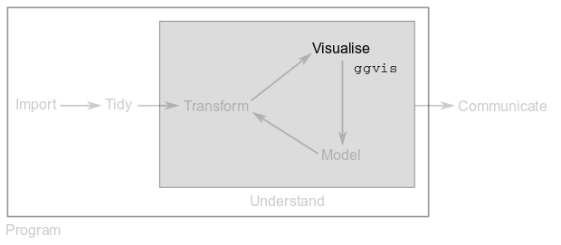

You must load packages tidyverse and ggvis.

### 5.1.1 Exercise 5.1

Result should look like the following table:

| id | chol | hdl | stab.glu | glyhb | location | age | gender | waist | hip | height | weight | diagnosis |
| --- | --- | --- | --- | --- | --- | --- | --- | --- | --- | --- | --- | --- |
| 1000 | 203 | 56 | 82 | 4.31 | Buckingham | 46 | female | 73.66 | 96.52 | 157.48 | 54.934 | healthy |
| 1001 | 165 | 24 | 97 | 4.44 | Buckingham | 29 | female | 116.84 | 121.92 | 162.56 | 98.972 | healthy |
| 1002 | 228 | 37 | 92 | 4.64 | Buckingham | 58 | female | 124.46 | 144.78 | 154.94 | 116.224 | healthy |
| 1003 | 78 | 12 | 93 | 4.63 | Buckingham | 67 | male | 83.82 | 96.52 | 170.18 | 54.026 | healthy |
| 1005 | 249 | 28 | 90 | 7.72 | Buckingham | 64 | male | 111.76 | 104.14 | 172.72 | 83.082 | diabetic |
| 1008 | 248 | 69 | 94 | 4.81 | Buckingham | 34 | male | 91.44 | 106.68 | 180.34 | 86.260 | healthy |
| 1011 | 195 | 41 | 92 | 4.84 | Buckingham | 30 | male | 116.84 | 124.46 | 175.26 | 86.714 | healthy |
| 1015 | 227 | 44 | 75 | 3.94 | Buckingham | 37 | male | 86.36 | 99.06 | 149.86 | 77.180 | healthy |
| 1016 | 177 | 49 | 87 | 4.84 | Buckingham | 45 | male | 86.36 | 101.60 | 175.26 | 75.364 | healthy |
| 1022 | 263 | 40 | 89 | 5.78 | Buckingham | 55 | female | 114.30 | 127.00 | 160.02 | 91.708 | healthy |

[output cut: 377 more lines]

| id <dbl> | chol <dbl> | hdl <dbl> | stab.glu <dbl> | glyhb <dbl> | location <chr> | age <dbl> | gender <chr> | waist <dbl> | hip <dbl> |  |
| --- | --- | --- | --- | --- | --- | --- | --- | --- | --- | --- |
| 1000 | 203 | 56 | 82 | 4.31 | Buckingham | 46 | female | 73.66 | 96.52 |  |
| 1001 | 165 | 24 | 97 | 4.44 | Buckingham | 29 | female | 116.84 | 121.92 |  |
| 1002 | 228 | 37 | 92 | 4.64 | Buckingham | 58 | female | 124.46 | 144.78 |  |
| 1003 | 78 | 12 | 93 | 4.63 | Buckingham | 67 | male | 83.82 | 96.52 |  |
| 1005 | 249 | 28 | 90 | 7.72 | Buckingham | 64 | male | 111.76 | 104.14 |  |
| 1008 | 248 | 69 | 94 | 4.81 | Buckingham | 34 | male | 91.44 | 106.68 |  |
| 1011 | 195 | 41 | 92 | 4.84 | Buckingham | 30 | male | 116.84 | 124.46 |  |
| 1015 | 227 | 44 | 75 | 3.94 | Buckingham | 37 | male | 86.36 | 99.06 |  |
| 1016 | 177 | 49 | 87 | 4.84 | Buckingham | 45 | male | 86.36 | 101.60 |  |
| 1022 | 263 | 40 | 89 | 5.78 | Buckingham | 55 | female | 114.30 | 127.00 |  |

1-10 of 387 rows | 1-10 of 13 columns

## 5.2 Plotting with ggplot

In order to plot with package **ggplot**, we need the **%>%** operator to channel information into function **ggplot**. This creates a blank canvas on top of which we add layers of information and polish our plot. Note that, The **ggplot** functions are chained by the **+** operator!

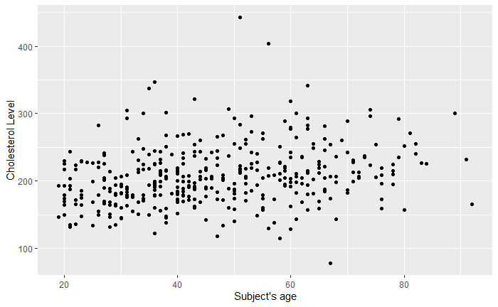

```r
diab %>%
  ggplot(aes(x = age, y = chol)) +
  geom_point() +
  xlab("Subject's age") +
  ylab("Cholesterol Level")
```

The above example feeds function **ggplot** with the **diab** table, indicates that we want to compare age with cholesterol levels (**aes** stands for aesthetic), uses **geom_points** to generate a scatter plot with the data and polishes the plot by providing custom axis labels (**xlab** and **ylab**).

You will see that following this syntax allows you to generate many different types of plots. It is just a matter of changing the layer function or adding more layers to your plot:

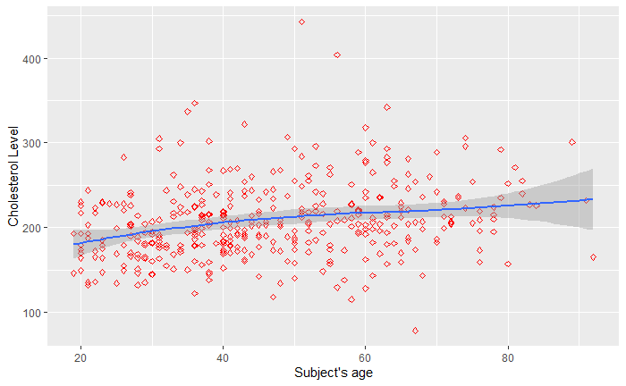

```r
diab %>%
  ggplot(aes(x = age, y = chol )) +
  geom_point(shape=23, color='red') +
  geom_smooth() +
  xlab("Subject's age") +
  ylab("Cholesterol Level")
```

See how the above example adds a **geom_smooth** layer on top of **geom_point**. Also, note that it is possible to further polish the plot via parameters that are specific to each type of layer. For example, we can change the color and shape of points through parameters color and shape of function **geom_point**.

## 5.3 Bar plots

Bar plots are useful when we want to graphically show counts of a discrete or categorical variable. For example, to see the number of male and female subjects in **diab** we do:

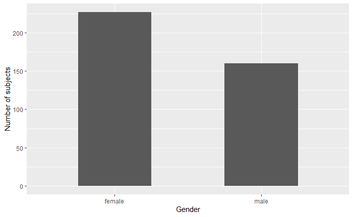

```r
diab %>%
  ggplot(aes(x=gender)) +
  geom_bar(width = 0.5) +
  xlab("Gender") +
  ylab("Number of subjects")
```

Note how the **width** parameter of **geom_bar** has been used to plot narrow bars.

We can also see the number of diabetic and healthy subjects:

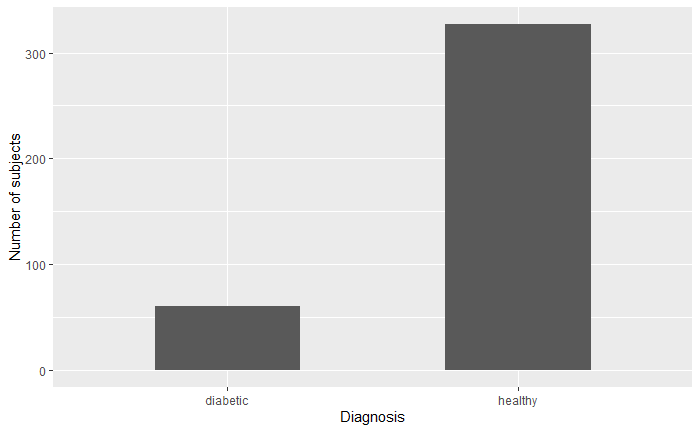

```r
diab %>%
  ggplot(aes(x=diagnosis)) +
  geom_bar(width = 0.5) +
  xlab("Diagnosis") +
  ylab("Number of subjects")
```

Finally, we can also use the y-axis of bar plots to show information other than counts. For example, we can contrast the average cholesterol levels of men and women:

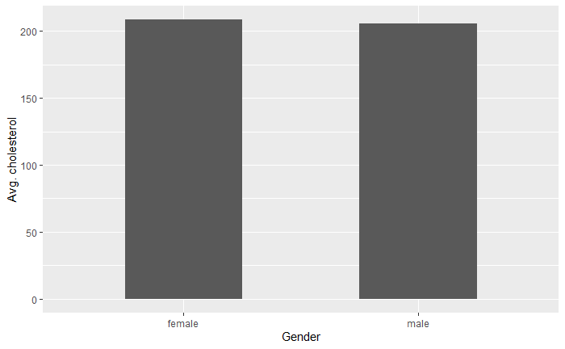

```r
diab %>%
  group_by(gender) %>%
  summarise(avg_chol = mean(chol)) %>%
  ggplot(aes(x = gender, y = avg_chol)) +
  geom_col(width = 0.5) +
  xlab("Gender") +
  ylab("Avg. cholesterol")
```

Note how data transformations can be applied on the fly and piped to **ggplot**.

## 5.4 Scatter plots and regressions

Scatter plots allow us to study the relationships between two numerical variables and regressions try to find the curve that best describes how x is related to y.

Let’s see how weight and waist measurements are related:

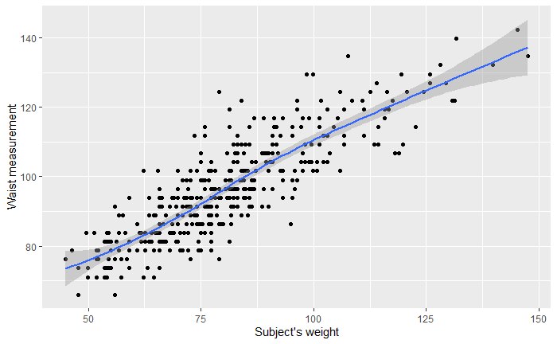

```r
diab %>%
  ggplot(aes(x = weight, y = waist)) +
  geom_point() +
  geom_smooth() +
  xlab("Subject's weight") +
  ylab("Waist measurement")
```

In the above example, **geom_point** is in charge of the scatter plot and **geom_smooth** finds a curve that follows the points and summarizes the observed trend. By default, a standard error grey band is shown to indicate how much we can trust the blue regression curve.

If we want to have more control over the type of curve that is fitted to the points, we can use the **method** parameter. For example, to fit a straight line to the above plot, we have to use a linear regression model (**“lm”**):

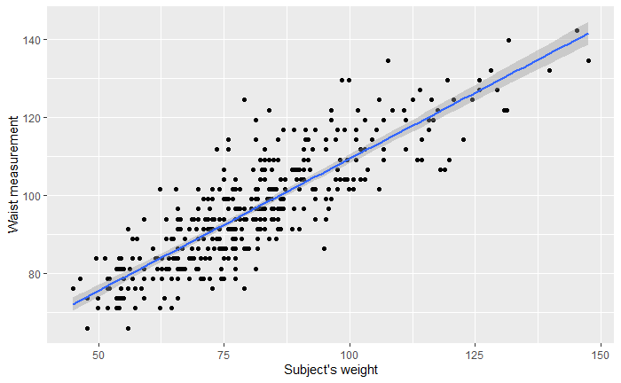

```r
diab %>%
  ggplot(aes(x = weight, y = waist)) +
  geom_point() +
  geom_smooth(method = "lm") +
  xlab("Subject's weight") +
  ylab("Waist measurement")
```

Even though a scatter plot is intrinsically in 2 dimensions, we can add more layers of information to learn more about our data. For example, we can color our points according to the subject’s diagnosis and adjust their size by glyhb:

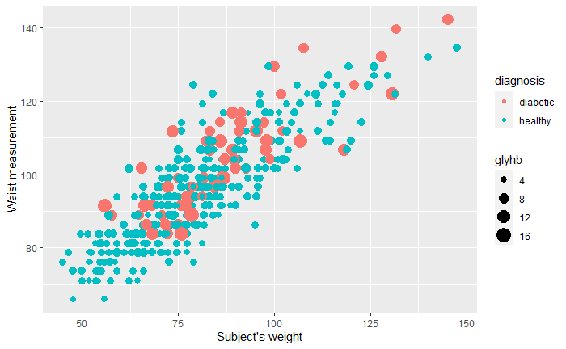

```r
diab %>%
  ggplot(aes(x = weight, y = waist, color = diagnosis, size = glyhb)) +
  geom_point() +
  xlab("Subject's weight") +
  ylab("Waist measurement")
```

## 5.5 Line graphs

Line plots are similar to scatter plots, but the variable in the x-axis is sorted and points are connected in order with a line:

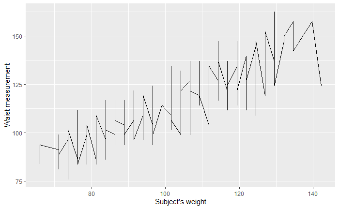

```r
diab %>%
  ggplot(aes(x = waist, y = hip)) +
  geom_line() +
  xlab("Subject's weight") +
  ylab("Waist measurement")
```

It is very common to add a point layer on top of line plots:

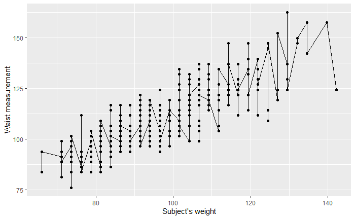

```r
diab %>%
  ggplot(aes(x = waist, y = hip)) +
  geom_line() +
  geom_point() +
  xlab("Subject's weight") +
  ylab("Waist measurement")
```